# Carboxylesterase Proteins Analysis - Skyler Liu

# Scientific Question

How do the sequences and different types of bonding contribute to the structural similarities and differences between the 2H7C and 2HRQ (Homo sapien) and the 5MIF (Tuber melanosporum) carboxylesterase protein structures?

Carboxylesterases are enzymes that hydrolyze carboxylesters into their corresponding alcohol and carboxylic acid. These enzymes are important for detoxification and have been identified in all living organisms (Hatfield, 2016). In the black Perigord truffle (Tuber melanosporum), carboxylesterases are preferentially expressed during their symbiotic phase as this type of fungus has a mutualistic relationship with its host (Cavazzini, 2017). Unlike truffles, humans do not have mutualistic host relationships and instead, carboxylesterases can be used to metabolize drugs such as cocaine and heroin (Bencharit, 2006). In different species, carboxylesterases have different uses. In this project, I wanted to look at the bonds and the 5MIF structure contains cis-peptide bonds while the 2H7C and 2HRQ structures contain disulfide bridges. Cis-peptide bonds are found primarily in bends and turns but provide unfavorable contacts between adjacent amino acid residues (Stewart, 1990). On the other hand, disulfide bridges are formed specifically in between cysteine residues and are fundamental to the biological processes of the protein (Wiedemann, 2020). I chose two human carboxylesterase proteins that were bound in compounds because I want to know whether being in a compound would also affect the protein structure and binding.

# Scientific Hypothesis

If the FASTA and pdb sequences for 2H7C, 5MIF, and 2HRQ are aligned and the protein structure models are compared, then the amount and locations of their bonds between which amino acids can be determined and show how they contribute to the structural differences between species.

The first bioinformatics method that will be used is a pairw ise sequence alignment of the FASTA files which will be retrieved from the EMBL-EBI database. Multiple sequence alignment can be used to compare the conserved and variable sequences of carboxylesterases between the two species. In order to display this information, a sequence logo will be used with larger letters indicating conserved amino acids. The next bioinformatics method will be structural bioinformatics with data obtained from the Protein Databank to review the two different protein structures. 3-D protein measurements will also be used to visualize the proteins and their bonds.

# Package Descriptions

The packages that I will be needing include are below. How I installed the packages if I didn’t already have them was to go to the “Tools” tab and select “Install Packages” in the drop down menu. Then, I typed in the name of the package I wanted and hit the “Install” button. All of the packages below can be installed using that method. The packages can also be installed in chunk or the console with the install.packages() function but I use the other method to keep my workspace relatively free of clutter. Then, use the library() function to read in the packages.

BioStrings: I will use Biostrings to read in the FASTA files.

BiocManager: I will be using BiocManager for multiple sequence analysis to align the sequences.

msa: This is a BiocManager package that is needed for multiple sequence alignment specifically. I will be using the BiocManager package msa specifically for multiple sequence alignment.

ggseqlogo: I will be using ggseqlogo to create the sequence logos.

bio3d: I will be using bio3d for structural bioinformatics analysis.

NGLViewR: I will be using NGLViewR for visually displaying the protein structures.

```r
library(Biostrings)
library(BiocManager)
library(msa)
library(ggseqlogo)
library(bio3d)
library(NGLVieweR)
```

# Performing Bioinformatics Analyses

# Multiple Sequence Alignment

```r
# FASTA files obtained from EMBL-EBI. Read in FASTA files.
FASTA_5MIF <- readAAStringSet("5MIF.fasta", format = "fasta")
FASTA_2H7C <- readAAStringSet("2H7C.fasta", format = "fasta")
FASTA_2HRQ <- readAAStringSet("2HRQ.fasta", format = "fasta")
all_FASTA <- c(FASTA_5MIF, FASTA_2H7C, FASTA_2HRQ)

pwa <- msaMuscle(all_FASTA)

print(pwa, show = "complete")
```

```
MsaAAMultipleAlignment with 3 rows and 556 columns
    aln (1..85)                                                                           names
[1] ----------------MRFTILSVLAFSLPLVLAETPAPSCPVTNVTTPQLDPITQAYADAISSRPSLFAFPLPEIRDGYQSNVS 5MIF_1|Chains A, ...
[2] HPSSPPVVDTVHGKVLGKFVSLEGFAQPVAIFLG-IPFAKPPLGPLRFTPPQP-----AEPWSFVKNATSYPPMCTQDPKAGQL- 2H7C_1|Chains A, ...
[3] --SSPPVVDTVHGKVLGKFVSLEGFAQPVAIFLG-IPFAKPPLGPLRFTPPQP-----AEPWSFVKNATSYPPMCTQDPKAGQL- 2HRQ_1|Chains A, ...
Con --SSPPVVDTVHGKVLGKFVSLEGFAQPVAIFLG-IPFAKPPLGPLRFTPPQP-----AEPWSFVKNATSYPPMCTQDPKAGQL- Consensus

    aln (86..170)                                                                         names
[1] DPSTEFTTKILSLPVGPTGNVTAY-LYKPVSGEREKGKDLLPVIAYFHGGGWVFGGPKSYRGLITNLIRESGAAVFFVDYTLTPK 5MIF_1|Chains A, ...
[2] -LSELFTNRKENIPLKLSEDCLYLNIYTPADLTK---KNRLPVMVWIHGGGLMVGAASTYDGL--ALAAHENVVVVTIQYRLGIW 2H7C_1|Chains A, ...
[3] -LSELFTNRKENIPLKLSEDCLYLNIYTPADLTK---KNRLPVMVWIHGGGLMVGAASTYDGL--ALAAHENVVVVTIQYRLGIW 2HRQ_1|Chains A, ...
Con -LSELFTNRKENIPLKLSEDCLYLNIYTPADLTK---KNRLPVMVWIHGGGLMVGAASTYDGL--ALAAHENVVVVTIQYRLGIW Consensus

    aln (171..255)                                                                        names
[1] VAYPVPNEQC---------YAAVQWLLEHGEKLGVDPTNMGFGGDSAGGE----------------------------------- 5MIF_1|Chains A, ...
[2] GFFSTGDEHSRGNWGHLDQVAALRWVQDNIASFGGNPGSVTIFGESAGGESVSVLVLSPLAKNLFHRAISESGVALTSVLVKKGD 2H7C_1|Chains A, ...
[3] GFFSTGDEHSRGNWGHLDQVAALRWVQDNIASFGGNPGSVTIFGESAGGESVSVLVLSPLAKNLFHRAISESGVALTSVLVKKGD 2HRQ_1|Chains A, ...
Con GFFSTGDEHSRGNWGHLDQVAALRWVQDNIASFGGNPGSVTIFGESAGGESVSVLVLSPLAKNLFHRAISESGVALTSVLVKKGD Consensus

    aln (256..340)                                                                        names
[1] ----------------LSSSVSLLSIKRKTPLPKFQ------------------------------VLIYPATDLACESATFKEF 5MIF_1|Chains A, ...
[2] VKPLAEQIAITAGCKTTTSAVMVHCLRQKTEEELLETTLKMKFLSLDLQGDPRESQPLLGTVIDGMLLLKTPEELQAER-NFHTV 2H7C_1|Chains A, ...
[3] VKPLAEQIAITAGCKTTTSAVMVHCLRQKTEEELLETTLKMKFLSLDLQGDPRESQPLLGTVIDGMLLLKTPEELQAER-NFHTV 2HRQ_1|Chains A, ...
Con VKPLAEQIAITAGCKTTTSAVMVHCLRQKTEEELLETTLKMKFLSLDLQGDPRESQPLLGTVIDGMLLLKTPEELQAER-NFHTV Consensus

    aln (341..425)                                                                        names
[1] PNGPGLTTDEIRFAASLFTPDP-------------------------KSRLEDVASPGRASDEDLAK-------------FPETL 5MIF_1|Chains A, ...
[2] PYMVGINKQEFGWLIPMLMSYPLSEGQLDQKTAMSLLWKSYPLVCIAKELIPEATEKYLGGTDDTVKKKDLFLDLIADVMFGVPS 2H7C_1|Chains A, ...
[3] PYMVGINKQEFGWLIPMLMSYPLSEGQLDQKTAMSLLWKSYPLVCIAKELIPEATEKYLGGTDDTVKKKDLFLDLIADVMFGVPS 2HRQ_1|Chains A, ...
Con PYMVGINKQEFGWLIPMLMSYPLSEGQLDQKTAMSLLWKSYPLVCIAKELIPEATEKYLGGTDDTVKKKDLFLDLIADVMFGVPS Consensus

    aln (426..510)                                                                        names
[1] IVVA-----------------------EVDP---IRQQGED----FGRRLQKLGVRAAIIRVLGTIHGFASIDVLSEAPGAKATI 5MIF_1|Chains A, ...
[2] VIVARNHRDAGAPTYMYEFQYRPSFSSDMKPKTVIGDHGDELFSVFGAPFLKEGASEEEIRLSKMVMKFWANFARNGNPNGEGLP 2H7C_1|Chains A, ...
[3] VIVARNHRDAGAPTYMYEFQYRPSFSSDMKPKTVIGDHGDELFSVFGAPFLKEGASEEEIRLSKMVMKFWANFARNGNPNGEGLP 2HRQ_1|Chains A, ...
Con VIVARNHRDAGAPTYMYEFQYRPSFSSDMKPKTVIGDHGDELFSVFGAPFLKEGASEEEIRLSKMVMKFWANFARNGNPNGEGLP Consensus

    aln (511..556)                                 names
[1] ELIGYKFKKALH---------------------------------- 5MIF_1|Chains A, ...
[2] HWPEYNQKEGYLQIGANTQAAQKLKDKEVAFWTNLFAKKAVEKPPQ 2H7C_1|Chains A, ...
[3] HWPEYNQKEGYLQIGANTQAAQKLKDKEVAFWTNLFAK-------- 2HRQ_1|Chains A, ...
Con HWPEYNQKEGYLQIGANTQAAQKLKDKEVAFWTNLFAK-------- Consensus
```

```r
# Print out optimal global alignment for the sequences and the score. There are only global variables in this alignment and no local variables.
aln = pairwiseAlignment(pattern = c("FASTA_5MIF", "FASTA_2H7C", "FASTA_2HRQ"), subject = "FASTA_5MIF")
aln
```

```
Global PairwiseAlignmentsSingleSubject (1 of 3)
pattern: FASTA_5MIF
subject: FASTA_5MIF
score: 37.89096
```

```r
# Print optimal alignment and score
score(aln)
```

```
[1] 37.890965 -2.090368 -2.090368
```

```r
# code check for sequence length
nchar(FASTA_2H7C)
```

```
[1] 542
```

```r
nchar(FASTA_2HRQ)
```

```
[1] 532
```

```r
nchar(FASTA_5MIF)
```

```
[1] 347
```

# Sequence Logos

```r
# Multiple sequence alignment of the 3 FASTA files.
align <- msa(all_FASTA)
```

```
use default substitution matrix
```

[figure not shown]

```r
# Align them as characters rather than amino acids.
align_ch <- as.character(align)
# Create sequence logo.
seq_logo <- ggseqlogo(align_ch)
seq_logo
```

```r
# Check sequences at beginning without msa
head(FASTA_5MIF)
```

```
AAStringSet object of length 1:
    width seq                                                                              names
[1]   347 MRFTILSVLAFSLPLVLAETPAPSCPVTNVTTPQLDPIT...IRVLGTIHGFASIDVLSEAPGAKATIELIGYKFKKALH 5MIF_1|Chains A, ...
```

```r
head(FASTA_2H7C)
```

```
AAStringSet object of length 1:
    width seq                                                                              names
[1]   542 HPSSPPVVDTVHGKVLGKFVSLEGFAQPVAIFLGIPFAK...EGYLQIGANTQAAQKLKDKEVAFWTNLFAKKAVEKPPQ 2H7C_1|Chains A, ...
```

```r
head(FASTA_2HRQ)
```

```
AAStringSet object of length 1:
    width seq                                                                              names
[1]   532 SSPPVVDTVHGKVLGKFVSLEGFAQPVAIFLGIPFAKPP...HWPEYNQKEGYLQIGANTQAAQKLKDKEVAFWTNLFAK 2HRQ_1|Chains A, ...
```

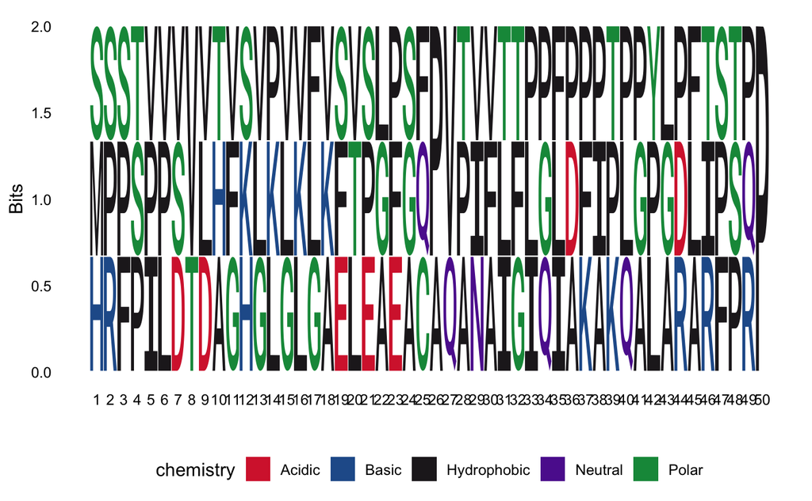

```r
# The sequence logo above is too crowded so it will need trimming for better visualization.
trim5mif <- substring(FASTA_5MIF, 1, 50)
trim2h7c <- substring(FASTA_2H7C, 1, 50)
trim2hrq <- substring(FASTA_2HRQ, 1, 50)
trimall <- c(trim5mif, trim2h7c, trim2hrq)


ggseqlogo(trimall)
```

# Structural Bioinformatics

```r
# Get pdb files and this will download them into your working directory.
ids <- c("5MIF", "2H7C", "2HRQ")
raw.files <- get.pdb(ids)
# Extract and align the chains we are interested in
files <- pdbsplit(raw.files, ids)
```

```r
# Read in the pdb files for each.
pdb5mif <- read.pdb("5MIF.pdb", maxlines = -1, multi = FALSE, rm.insert = FALSE,
         rm.alt = TRUE, ATOM.only = FALSE, hex = FALSE, verbose = TRUE)

pdb2h7c <- read.pdb("2H7C.pdb", maxlines = -1, multi = FALSE, rm.insert = FALSE,
         rm.alt = TRUE, ATOM.only = FALSE, hex = FALSE, verbose = TRUE)
```

```
   PDB has ALT records, taking A only, rm.alt=TRUE
```

```r
pdb2hrq <- read.pdb("2HRQ.pdb", maxlines = -1, multi = FALSE, rm.insert = FALSE,
         rm.alt = TRUE, ATOM.only = FALSE, hex = FALSE, verbose = TRUE)

# Start first structural alignment. I am providing my email as I do not have the muscle program installed.
struct.aln(pdb5mif, pdb2h7c, fixed.inds=NULL, mobile.inds=NULL,
           write.pdbs=TRUE, outpath = "fitlsq", prefix=c("fixed",
           "mobile"), max.cycles=10, cutoff=0.5,  web.args=list(email="sml010@ucsd.edu"))
```

```
Will try to align sequences online...

Job successfully submited (job ID: muscle-R20220606-043339-0934-24172823-p1m)
Waiting for job to finish...Done.

 Initial RMSD (1196 atoms): 50.269
 Cycle 1: 39 atoms rejected
  Mean: 45.8 Std: 19.5 Cut: 84.8
  RMSD (1157 of 1196 atoms): 48.025
 Cycle 2: 30 atoms rejected
  Mean: 42.9 Std: 17.9 Cut: 78.7
  RMSD (1127 of 1196 atoms): 46.725
 Cycle 3: 27 atoms rejected
  Mean: 41.6 Std: 16.9 Cut: 75.3
  RMSD (1100 of 1196 atoms): 45.706
```

[output cut: 262 more lines]

```r
# Perform structural alignment between 2 at a time with one as a fixed sequence (base) and one as a mobile sequence (to compare against the fixed). Repeat for the other combinations.
struct.aln(pdb5mif, pdb2hrq, fixed.inds=NULL, mobile.inds=NULL,
           write.pdbs=TRUE, outpath = "fitlsq", prefix=c("fixed",
           "mobile"), max.cycles=10, cutoff=0.5,  web.args=list(email="sml010@ucsd.edu"))
```

```
Will try to align sequences online...

Job successfully submited (job ID: muscle-R20220606-043620-0291-24974806-p2m)
Waiting for job to finish...Done.

 Initial RMSD (1196 atoms): 61.115
 Cycle 1: 61 atoms rejected
  Mean: 54.3 Std: 21.2 Cut: 96.6
  RMSD (1135 of 1196 atoms): 56.728
 Cycle 2: 61 atoms rejected
  Mean: 51.5 Std: 17.6 Cut: 86.7
  RMSD (1074 of 1196 atoms): 53.857
 Cycle 3: 36 atoms rejected
  Mean: 50.1 Std: 16 Cut: 82
  RMSD (1038 of 1196 atoms): 52.389
```

[output cut: 252 more lines]

```r
struct.aln(pdb2h7c, pdb2hrq, fixed.inds=NULL, mobile.inds=NULL,
           write.pdbs=TRUE, outpath = "fitlsq", prefix=c("fixed",
           "mobile"), max.cycles=10, cutoff=0.5,  web.args=list(email="sml010@ucsd.edu"))
```

```
Will try to align sequences online...

Job successfully submited (job ID: muscle-R20220606-043812-0802-70472669-p1m)
Waiting for job to finish...Done.

 Initial RMSD (3188 atoms): 50.671
 Cycle 1: 210 atoms rejected
  Mean: 42.9 Std: 20.3 Cut: 83.5
  RMSD (2978 of 3188 atoms): 46.186
 Cycle 2: 198 atoms rejected
  Mean: 40.4 Std: 17.3 Cut: 74.9
  RMSD (2780 of 3188 atoms): 42.581
 Cycle 3: 173 atoms rejected
  Mean: 37.7 Std: 15.3 Cut: 68.3
  RMSD (2607 of 3188 atoms): 39.514
```

[output cut: 240 more lines]